# customers_segmentation_exam slides

### Data analysis & presentation

> Who are the customers composing the 4 segments?

Based on the analysis of the `customers` dataset, prepare a slides deck to present your conclusions to the Marketing manager Debrah. The presentation must contain **5 slides maximum** (including the title slide). Feel free to choose the slide app of your choice.

ℹ️ Debrah is in fond of illustrations and statistics!

⚠️ Save your presentation in the current directory!

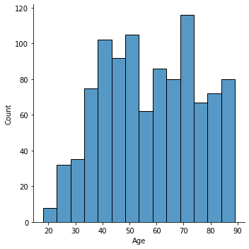

```python
import seaborn as sns
sns.displot(dfspendinghigh["Age"])
```

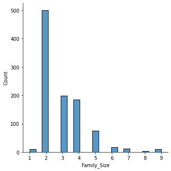

```python
import seaborn as sns
sns.displot(dfspendinghigh["Family_Size"])
```

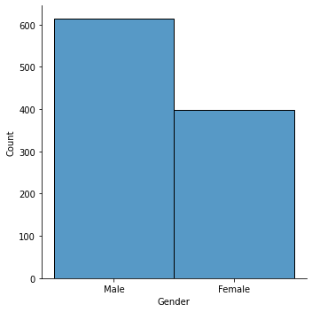

```python
import seaborn as sns
sns.displot(dfspendinghigh["Gender"])
```

The biggest spenders at Las Wagones are in between 35 years old and 90 years old, with a spike for customers aged between 68 and 74. The buyers who spend the most are men who have a partner and are without children, although many women are also good customers!!!

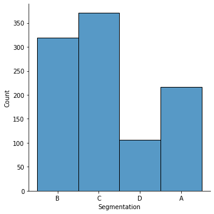

```python
import seaborn as sns
sns.displot(dfspendinghigh["Segmentation"])
```

The Segments B and C are the biggest spenders at Las Wagones

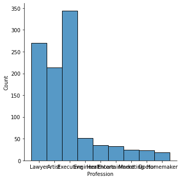

```python
import seaborn as sns
sns.displot(dfspendinghigh["Profession"])
```

Lawyers, Artists and Executives are the professions that spend the most at Las Wagones

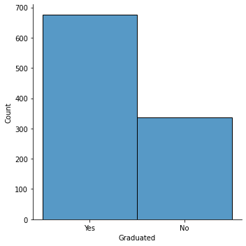

```python
sns.displot(dfspendinghigh["Graduated"])
```

Within high spenders at Las Wagones, about two thirds have a diploma.

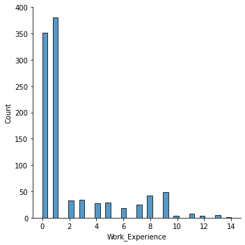

```python
sns.displot(dfspendinghigh["Work_Experience"])
```

Most High Spenders at Las Wagones have between 0 and 1 year of experience. This does not seem very relevant considering the distributions plot we obtained for the age feature. Maybe there is an issue extracting and potentially having to sum up work experience from the initial database. To be checked...

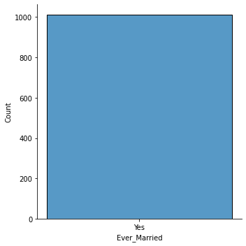

```python
sns.displot(dfspendinghigh["Ever_Married"])
```

What a happy coincidence! The customers who spend the most at Las Wagones all married at least once during their lifetime.